# WASH IPD Aim-2 figure and tables

Andrew Mertens

### Overall summary of results:

Most study-specific estimates are null, with inconsistent direction of effects in significant associations. Estimates pooled over multiple studies were also null, except for a small and marginally significant association between any pathogen in any sample and lower child height-for-age Z-scores (which is significant without adjustment for confounders).

### Overall notes on data availability:

- Odagiri et al. 2016 only measured weight, so we only have WAZ, and Reese only measures/shared height, so we only have HAZ.
- The tables at the bottom of the report show the number of samples and number of health outcomes by study the column for both positive sample and diarrhea measure is likely the limiting factor for sparse analyses.

### Notes on analysis

- The analysis included baseline (pre-intervention) measurements.
- All primary estimates are adjusted for intervention arm and child and household covariates.
- Only child health measurements taken after environmental samples were used.
- Diarrhea measurements must have occured after environmental samples, but within 4 months of environmental sample collection.
- Environmental samples were matched to the most proximate child health outcome, without using multiple measurements. For example, environmental samples at baseline were matched to child anthropometry and midline, but not endline.

### Notes on time ordering of environmental samples and child health outcomes, and data merging by study

#### WASH Benefits Bangladesh

- Endline (year 2) anthropometry and diarrhea was used for Kwong et al. 2021 (STH samples)
- World Bank substudy diarrhea and anthropometry was used for Boehm et al. 2016
- R01 substudy diarrhea and anthropometry was used for Fuhrmeister et al. 2020. The substudy was conducted over 8 rounds taken around 3 months apart, with environmental sampling occurring in rounds 3 and 4. Environmental samples were merged to diarrhea from the subsequent round and anthropometry from the main trial endline (year two) sampling.

#### WASH Benefits Kenya

- Endline (year 2) anthropometry and diarrhea was used.

#### Mapsan

- The Mapsan trial had three sampling rounds, baseline, midline, and endline, each 12 months
- The Mapsan trial environmental sampling data is divided into three studies which had differences in samples, microbial targets, and sampling times, Holcomb et al 2020 (baseline and midline), Capone et al 2021 (baseline and endline), and Capone et al 2021 in prep. (baseline and midline).
- Diarrhea was used from concurrent rounds, while anthropometry was used from subsequent rounds, except for endline environmental samples, where concurrent anthropometry was used.

#### Gram Vikas

- Sampling rounds were approximately 4 months apart, so anthropometry data was taken from subsequent round, and diarrhea data was taken from either the current or subsequent round, based on which sample was taken after but closer to the environmental sampling, and within 4 months.

# Primary figures

## Diarrhea

#### Adjusted associations between diarrhea and any pathogen or MST marker

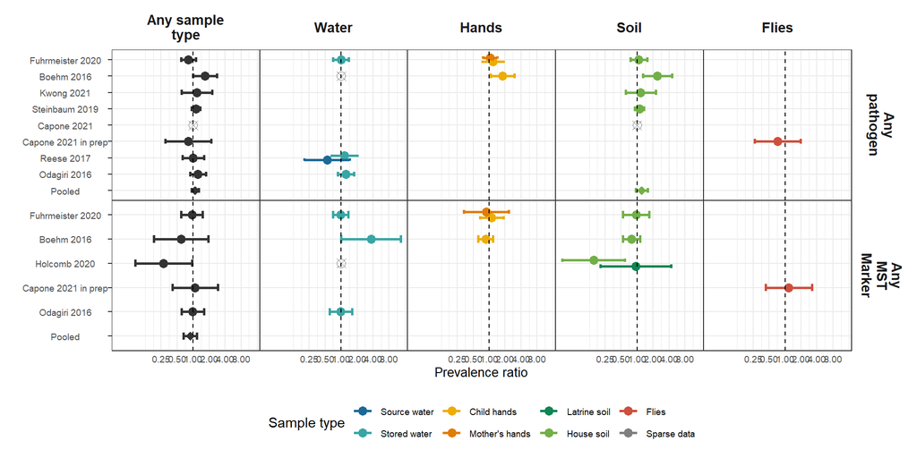

#### Adjusted associations between diarrhea and types of pathogens

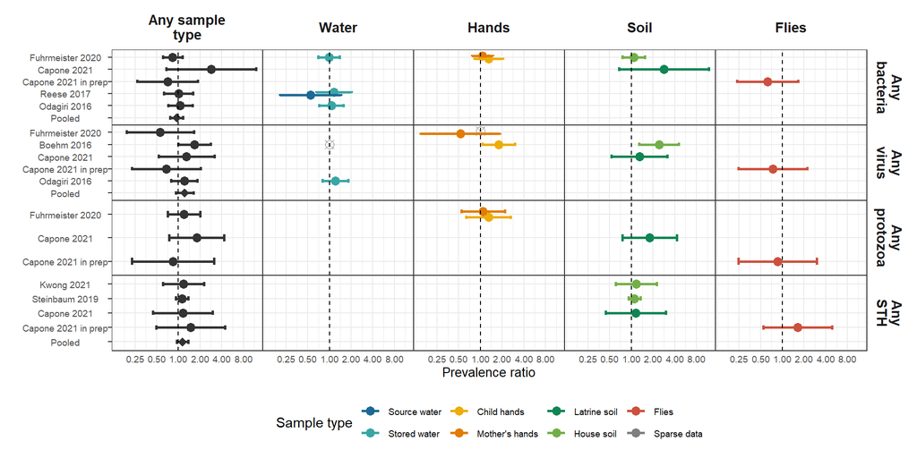

#### Adjusted associations between diarrhea and types of MST markers

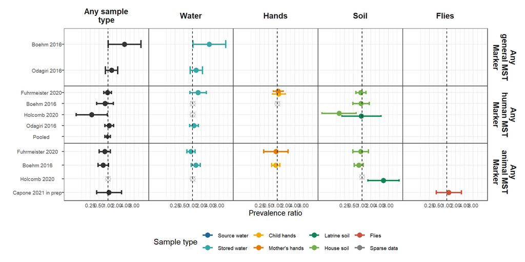

## Height-for-age Z-scores

#### Adjusted associations between HAZ and any pathogen or MST marker

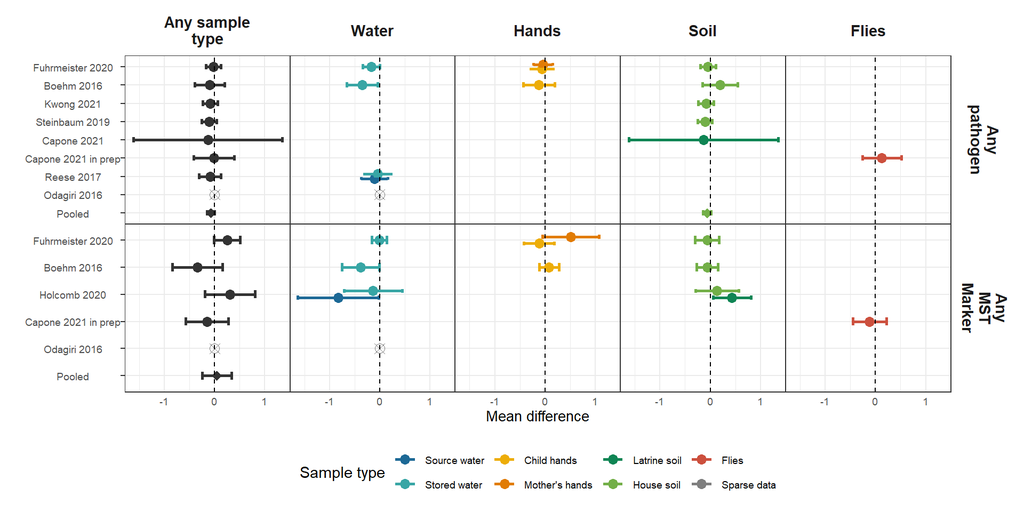

#### Adjusted associations between HAZ and types of pathogens

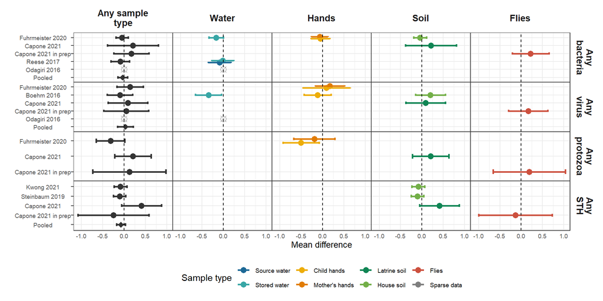

#### Adjusted associations between HAZ and types of MST markers

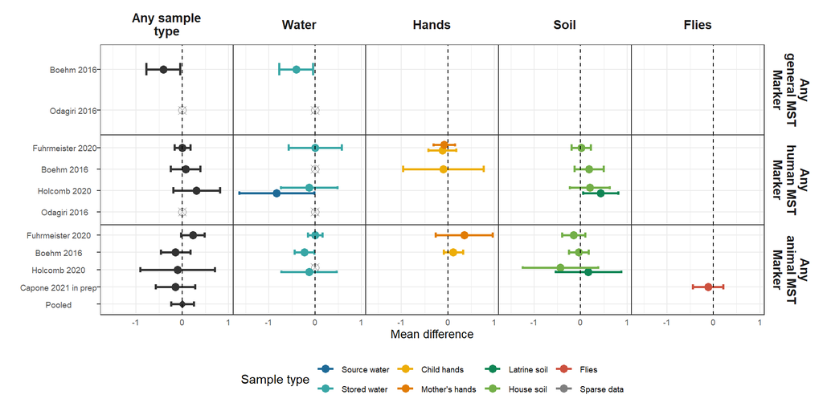

# Secondary figures

## Diarrhea

#### Adjusted associations between diarrhea and specific pathogens

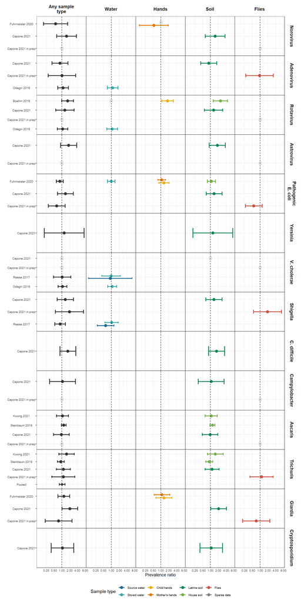

#### Unadjusted associations between diarrhea and any pathogen or MST marker

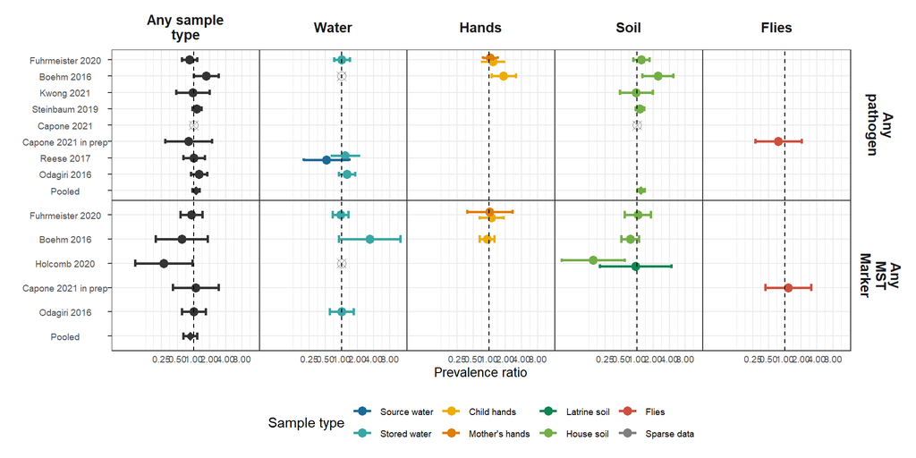

## Height-for-age Z-scores

#### Adjusted associations between HAZ and specific pathogens

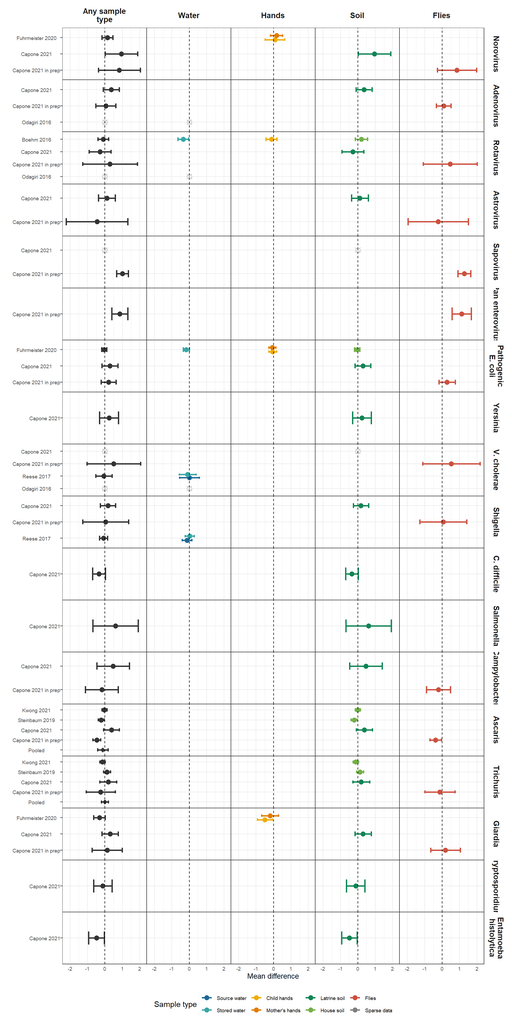

#### Unadjusted associations between HAZ and any pathogen or MST marker

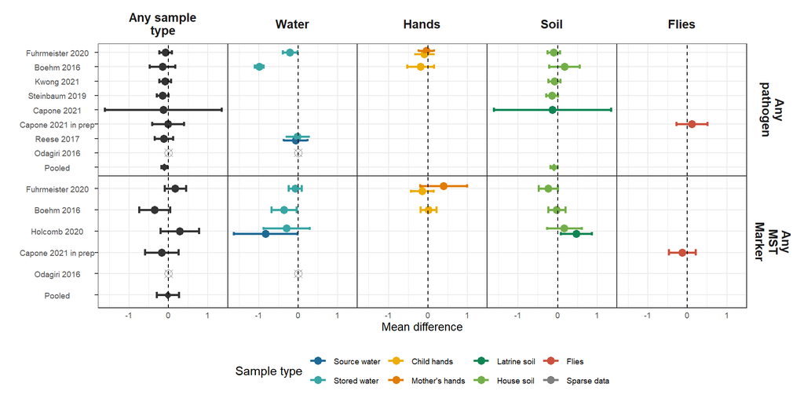

#### Adjusted associations between stunting and any pathogen or MST marker

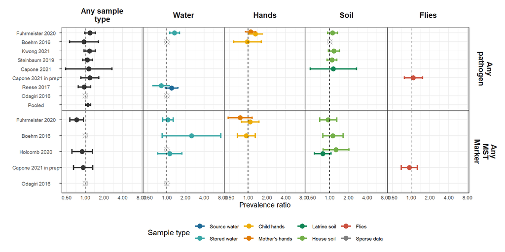

## Weight-for-height Z-score

#### Adjusted associations between WHZ and any pathogen or MST marker

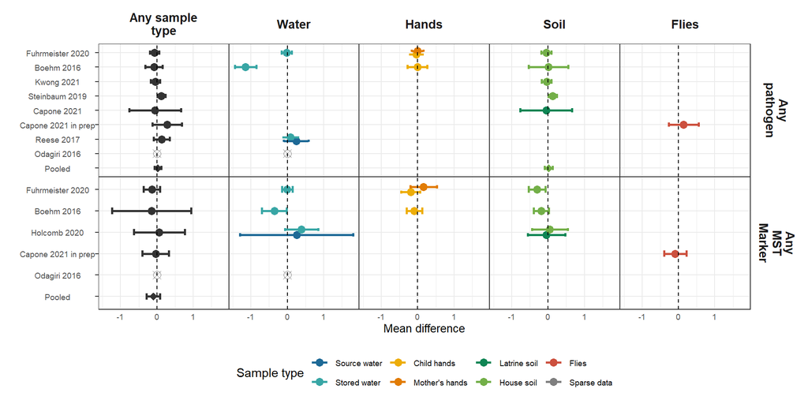

#### Adjusted associations between wasting and any pathogen or MST marker

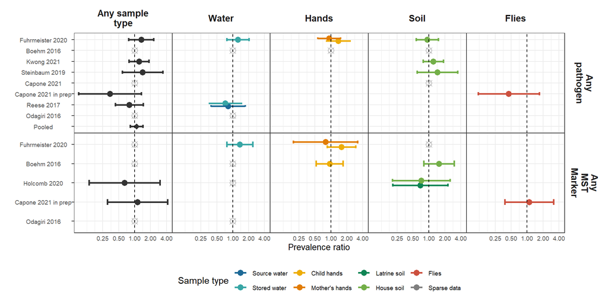

## Weight-for-age Z-score

#### Adjusted associations between WAZ and any pathogen or MST marker

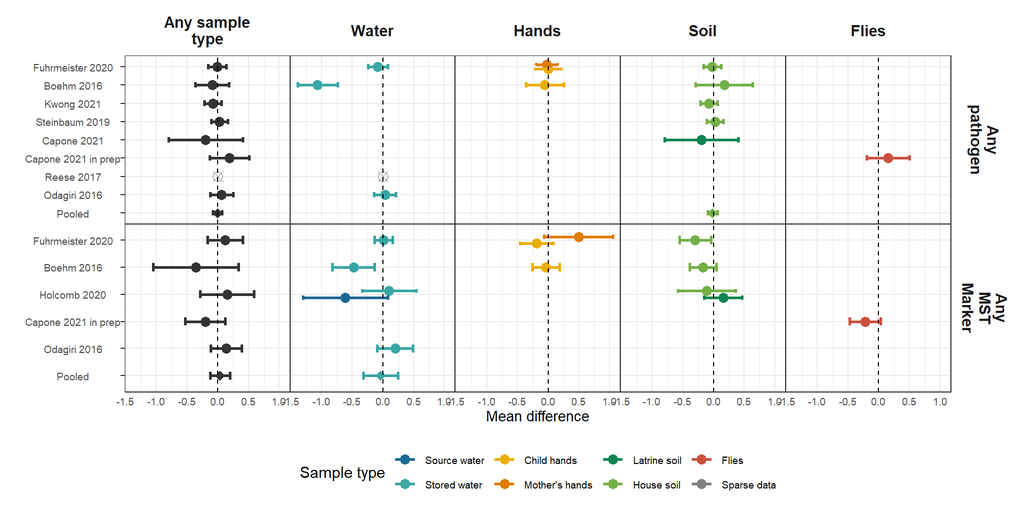

#### Adjusted associations between Underweight and any pathogen or MST marker

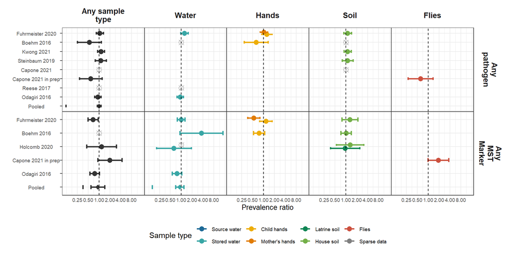

# Tables

## Data availability tables

### Any sample type, any pathogen

| study | sample | target | N samples | N sample pos. | N diar. meas. | N diar. pos. | N sample. and diar. pos. | N haz |
| --- | --- | --- | --- | --- | --- | --- | --- | --- |
| Fuhrmeister 2020 | any sample type | Any pathogen | 1,643 | 1,180 | 1,590 | 188 | 128 | 857 |
| Boehm 2016 | any sample type | Any pathogen | 497 | 34 | 412 | 99 | 11 | 411 |
| Kwong 2021 | any sample type | Any pathogen | 2,543 | 1,901 | 703 | 43 | 29 | 758 |
| Steinbaum 2019 | any sample type | Any pathogen | 2,234 | 414 | 1,874 | 485 | 97 | 1,761 |
| Capone 2021 | any sample type | Any pathogen | 566 | 531 | 167 | 21 | 20 | 253 |
| Capone 2021 in prep | any sample type | Any pathogen | 487 | 285 | 195 | 19 | 10 | 213 |
| Reese 2017 | any sample type | Any pathogen | 2,115 | 433 | 973 | 70 | 20 | 578 |
| Odagiri 2016 | any sample type | Any pathogen | 4,825 | 3,787 | 2,038 | 188 | 117 | 0 |

### Any sample type, any MST

| study | sample | target | N samples | N sample pos. | N diar. meas. | N diar. pos. | N sample. and diar. pos. | N haz |
| --- | --- | --- | --- | --- | --- | --- | --- | --- |
| Fuhrmeister 2020 | any sample type | Any MST | 1,636 | 1,533 | 1,583 | 188 | 175 | 850 |
| Boehm 2016 | any sample type | Any MST | 497 | 490 | 412 | 99 | 97 | 411 |
| Holcomb 2020 | any sample type | Any MST | 454 | 400 | 140 | 12 | 8 | 200 |
| Capone 2021 in prep | any sample type | Any MST | 487 | 266 | 195 | 19 | 11 | 213 |
| Odagiri 2016 | any sample type | Any MST | 4,825 | 4,672 | 2,038 | 188 | 174 | 0 |

### Soil samples, any pathogen

| study | sample | target | N samples | N sample pos. | N diar. meas. | N diar. pos. | N sample. and diar. pos. | N haz |
| --- | --- | --- | --- | --- | --- | --- | --- | --- |
| Fuhrmeister 2020 | S | Any pathogen | 1,320 | 824 | 1,277 | 141 | 94 | 688 |
| Boehm 2016 | S | Any pathogen | 496 | 7 | 412 | 99 | 4 | 411 |
| Kwong 2021 | S | Any pathogen | 2,543 | 1,901 | 703 | 43 | 29 | 758 |
| Steinbaum 2019 | S | Any pathogen | 2,278 | 418 | 1,909 | 498 | 97 | 1,797 |

### Soil samples, any MST

| study | sample | target | N samples | N sample pos. | N diar. meas. | N diar. pos. | N sample. and diar. pos. | N haz |
| --- | --- | --- | --- | --- | --- | --- | --- | --- |
| Fuhrmeister 2020 | S | Any MST | 1,169 | 1,054 | 1,133 | 125 | 113 | 607 |
| Boehm 2016 | S | Any MST | 496 | 367 | 412 | 99 | 67 | 411 |
| Holcomb 2020 | S | Any MST | 358 | 229 | 117 | 10 | 2 | 145 |

### Water samples, any pathogen

| study | sample | target | N samples | N sample pos. | N diar. meas. | N diar. pos. | N sample. and diar. pos. | N haz |
| --- | --- | --- | --- | --- | --- | --- | --- | --- |
| Fuhrmeister 2020 | W | Any pathogen | 1,315 | 490 | 1,268 | 160 | 60 | 690 |
| Boehm 2016 | W | Any pathogen | 491 | 3 | 408 | 97 | 1 | 407 |
| Reese 2017 | W | Any pathogen | 1,994 | 289 | 880 | 65 | 16 | 537 |
| Odagiri 2016 | W | Any pathogen | 4,825 | 3,787 | 2,038 | 188 | 117 | 0 |

### Water samples, any MST

| study | sample | target | N samples | N sample pos. | N diar. meas. | N diar. pos. | N sample. and diar. pos. | N haz |
| --- | --- | --- | --- | --- | --- | --- | --- | --- |
| Fuhrmeister 2020 | W | Any MST | 1,290 | 891 | 1,243 | 157 | 107 | 674 |
| Boehm 2016 | W | Any MST | 489 | 458 | 406 | 97 | 95 | 405 |
| Holcomb 2020 | W | Any MST | 413 | 70 | 135 | 13 | 1 | 170 |
| Odagiri 2016 | W | Any MST | 4,825 | 4,672 | 2,038 | 188 | 174 | 0 |

## Data checking table

This table is primarily for internal data checking purposes.

| study | reese | capone | holcomb | fuhrmeister | boehm | kwong | steinbaum | odagiri |
| --- | --- | --- | --- | --- | --- | --- | --- | --- |
| env_samples_before_merge | 3452 | 355 | 726 | 2606 | 1497 | 1396 | 2107 | 60 |
| env_HH_before_merge | 828 | 130 | 199 | 597 | 501 | 1396 | 2107 | 60 |
| diar_samples_before_merge | 2024 | 2640 | 1840 | 2452 | 1957 | 8711 | 7015 | 31538 |
| haz_samples_before_merge | 1062 | 2320 | 1651 | 4584 | 4693 | 4583 | 6801 | 28656 |
| env_samples_after_merge | 3439 | 671 | 731 | 2591 | 1497 | 1371 | 2059 | 60 |
| env_HH_after_merge | 824 | 244 | 147 | 594 | 501 | 1371 | 2059 | 60 |
| diar_samples_after_merge | 2087 | 483 | 250 | 1598 | 412 | 2535 | 2234 | 16970 |
| haz_samples_after_merge | 578 | 319 | 202 | 859 | 411 | 1353 | 2135 | 15424 |
| samples_with_diar_after_merge | 3439 | 321 | 671 | 2467 | 1241 | 1371 | 2030 | 60 |
| samples_with_haz_after_merge | 967 | 257 | 475 | 2415 | 1238 | 1348 | 2029 | 60 |
| samples_with_ch_after_merge | 3439 | 380 | 729 | 2583 | 1241 | 1371 | 2059 | 60 |
| diar_samples_date_dropped | -14 | 35 | 71 | 0 | 0 | 670 | 129 | 6 |
| haz_samples_date_dropped | 0 | 5 | 0 | 0 | 0 | 590 | 230 | 6 |
| percent_diar_samples_dropped | -3.11 | 81.70 | 86.41 | 34.83 | 78.95 | 70.90 | 68.15 | 46.19 |
| percent_haz_samples_dropped | 45.57 | 86.25 | 87.76 | 81.26 | 91.24 | 70.48 | 68.61 | 46.18 |
| percent_env_samples_with_diar | 99.62 | 90.42 | 92.42 | 94.67 | 82.90 | 98.21 | 96.35 | 100.00 |
| percent_env_samples_with_haz | 28.01 | 72.39 | 65.43 | 92.67 | 82.70 | 96.56 | 96.30 | 100.00 |
| percent_env_samples_with_ch | 99.62 | 107.04 | 100.41 | 99.12 | 82.90 | 98.21 | 97.72 | 100.00 |
| per_diar_samples_date_dropped | -0.41 | 10.90 | 10.58 | 0.00 | 0.00 | 48.87 | 6.35 | 10.00 |
| per_haz_samples_date_dropped | 0.00 | 1.95 | 0.00 | 0.00 | 0.00 | 43.77 | 11.34 | 10.00 |